# Confirmatory factor analysis (practical)

Note updated January 17, 2024

Wan Nor Arifin (wnarifin@usm.my), Biostatistics and Research Methodology Unit, Universiti Sains Malaysia Website: wnarifin.github.io

This work is licensed under a [Creative Commons Attribution-ShareAlike 4.0 International License](http://creativecommons.org/licenses/by-sa/4.0/).

# 1 Practical

In this practical session, we are going to confirm our model based on the EFA findings. The same data set, “Attitude_Statistics v3.sav” will be used. View the original questionnaire “Attitude_Statistics v3 Questions.pdf”

We will focus on:

- Model fit by fit indices
- Localized areas of misfit
- Parameter estimates: Factor loadings and correlations
- Composite reliability Omega

# 2 Preliminaries

## 2.1 Load libraries

We are going to use `psych` (Revelle, 2023), `lavaan` version 0.6.16 (Rosseel, Jorgensen, & Rockwood, 2023), `semTools` version 0.5.6 (Jorgensen, Pornprasertmanit, Schoemann, & Rosseel, 2022) and `semPlot` version 1.1.6 (Epskamp, 2022) in our analysis. These packages must be installed from downloaded packages from CRAN at https://cran.r-project.org/.

Make sure you already installed all of them before loading the packages.

```r
library(foreign)
library(psych)
library(lavaan)  # for CFA
library(semTools)  # for additional functions in SEM
library(semPlot)  # for path diagram
```

## 2.2 Load data set

We include only good items from **PA1** and **PA2** in `data.cfa` data frame.

```r
data = read.spss("Attitude_Statistics v3.sav", F, T)  # Shortform
# Include selected items from PA1 & PA2 in "data.cfa"
data.cfa = data[c("Q4","Q5","Q6","Q7","Q8","Q9","Q10","Q11")]
str(data.cfa)
```

```
'data.frame':   150 obs. of  8 variables:
 $ Q4 : num  3 3 1 4 2 3 3 2 4 4 ...
  ..- attr(*, "value.labels")= Named num [1:5] 5 4 3 2 1
  .. ..- attr(*, "names")= chr [1:5] "STRONGLY AGREE" "AGREE" "NEUTRAL" "DISAGREE" ...
 $ Q5 : num  4 4 1 3 5 4 4 3 3 4 ...
  ..- attr(*, "value.labels")= Named num [1:5] 5 4 3 2 1
  .. ..- attr(*, "names")= chr [1:5] "STRONGLY AGREE" "AGREE" "NEUTRAL" "DISAGREE" ...
 $ Q6 : num  4 4 1 2 1 4 3 3 4 5 ...
  ..- attr(*, "value.labels")= Named num [1:5] 5 4 3 2 1
  .. ..- attr(*, "names")= chr [1:5] "STRONGLY AGREE" "AGREE" "NEUTRAL" "DISAGREE" ...
 $ Q7 : num  3 4 1 2 4 4 4 2 3 4 ...
  ..- attr(*, "value.labels")= Named num [1:5] 5 4 3 2 1
  .. ..- attr(*, "names")= chr [1:5] "STRONGLY AGREE" "AGREE" "NEUTRAL" "DISAGREE" ...
 $ Q8 : num  3 3 4 2 5 3 3 3 3 4 ...
  ..- attr(*, "value.labels")= Named num [1:5] 5 4 3 2 1
  .. ..- attr(*, "names")= chr [1:5] "STRONGLY AGREE" "AGREE" "NEUTRAL" "DISAGREE" ...
 $ Q9 : num  3 3 4 2 5 4 3 4 5 4 ...
  ..- attr(*, "value.labels")= Named num [1:5] 5 4 3 2 1
  .. ..- attr(*, "names")= chr [1:5] "STRONGLY AGREE" "AGREE" "NEUTRAL" "DISAGREE" ...
 $ Q10: num  3 3 5 2 3 4 3 4 4 4 ...
  ..- attr(*, "value.labels")= Named num [1:5] 5 4 3 2 1
  .. ..- attr(*, "names")= chr [1:5] "STRONGLY AGREE" "AGREE" "NEUTRAL" "DISAGREE" ...
 $ Q11: num  4 4 1 3 4 4 3 3 4 4 ...
  ..- attr(*, "value.labels")= Named num [1:5] 5 4 3 2 1
  .. ..- attr(*, "names")= chr [1:5] "STRONGLY AGREE" "AGREE" "NEUTRAL" "DISAGREE" ...
```

```r
dim(data.cfa)
```

```
[1] 150   8
```

```r
names(data.cfa)
```

```
[1] "Q4"  "Q5"  "Q6"  "Q7"  "Q8"  "Q9"  "Q10" "Q11"
```

```r
head(data.cfa)
```

```
  Q4 Q5 Q6 Q7 Q8 Q9 Q10 Q11
1  3  4  4  3  3  3   3   4
2  3  4  4  4  3  3   3   4
3  1  1  1  1  4  4   5   1
4  4  3  2  2  2  2   2   3
5  2  5  1  4  5  5   3   4
6  3  4  4  4  3  4   4   4
```

# 3 Confirmatory factor analysis

## 3.1 Preliminary steps

**Descriptive statistics**

Check minimum/maximum values per item, and screen for any missing values,

```r
describe(data.cfa)
```

```
    vars   n mean   sd median trimmed  mad min max range  skew kurtosis   se
Q4     1 150 2.81 1.17      3    2.78 1.48   1   5     4  0.19    -0.81 0.10
Q5     2 150 3.31 1.01      3    3.32 1.48   1   5     4 -0.22    -0.48 0.08
Q6     3 150 3.05 1.09      3    3.05 1.48   1   5     4 -0.04    -0.71 0.09
Q7     4 150 2.92 1.19      3    2.92 1.48   1   5     4 -0.04    -1.06 0.10
Q8     5 150 3.33 1.00      3    3.34 1.48   1   5     4 -0.08    -0.12 0.08
Q9     6 150 3.44 1.05      3    3.48 1.48   1   5     4 -0.21    -0.32 0.09
Q10    7 150 3.31 1.10      3    3.36 1.48   1   5     4 -0.22    -0.39 0.09
Q11    8 150 3.35 0.94      3    3.37 1.48   1   5     4 -0.31    -0.33 0.08
```

Note that all *n* = 150, no missing values. `min`–`max` cover the whole range of response options.

% of response to options per item,

```r
response.frequencies(data.cfa)
```

```
        1     2    3    4     5 miss
Q4  0.140 0.280 0.30 0.19 0.093    0
Q5  0.040 0.167 0.35 0.33 0.113    0
Q6  0.080 0.233 0.33 0.26 0.093    0
Q7  0.133 0.267 0.23 0.29 0.080    0
Q8  0.047 0.100 0.48 0.23 0.147    0
Q9  0.047 0.093 0.42 0.25 0.187    0
Q10 0.073 0.107 0.42 0.23 0.167    0
Q11 0.027 0.153 0.35 0.39 0.087    0
```

All response options are used, and there are no missing values.

**Multivariate normality**

This is done to check the multivariate normality of the data. If the data are normally distributed, we may use maximum likelihood (ML) estimation method for the CFA. In `lavaan`, we have a number of alternative estimation methods (the full list is available at http://lavaan.ugent.be/tutorial/est.html or by typing `?lavOptions`). Two common alternatives are:

1. **MLR** (robust ML), suitable for complete and incomplete, non-normal data (Rosseel et al., 2023).
2. **WLSMV** (robust weighted least squares), suitable for categorical response options (e.g. dichotomous, polytomous, ordinal (Brown, 2015))

```r
mardia(data.cfa)
```

```
Call: mardia(x = data.cfa)

Mardia tests of multivariate skew and kurtosis
Use describe(x) the to get univariate tests
n.obs = 150   num.vars =  8
b1p =  11.37   skew =  284.27  with probability  <=  2.3e-15
 small sample skew =  291.24  with probability <=  2.9e-16
b2p =  96.9   kurtosis =  8.18  with probability <=  2.2e-16
```

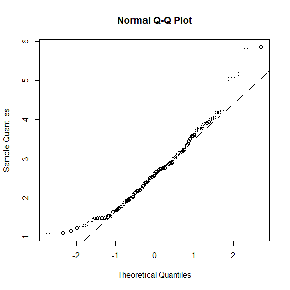

the data are not multivariate normal (`kurtosis` > 5, *P* < 0.05). We will use **MLR** in our analysis.

## 3.2 Step 1

**Specify the measurement model**

Specify the measurement model according to `lavaan` syntax.

```r
model = "
PA1 =~ Q4 + Q5 + Q6 + Q7 + Q11
PA2 =~ Q8 + Q9 + Q10
"
```

`=~` indicates “measured by”, thus the items represent the factor.

By default, `lavaan` will correlate PA1 and PA2 (i.e. `PA1 ~~ PA2`), somewhat similar to oblique rotation in EFA. `~~` means “correlation”. We will use `~~` when we add correlated errors later.

## 3.3 Step 2

**Fit the model**

Here, we fit the specified model. By default, marker indicator variable approach[^1] is used in `lavaan` to scale a factor[^2]. We use **MLR** as the estimation method.

```r
cfa.model = cfa(model, data = data.cfa, estimator = "MLR")
# cfa.model = cfa(model, data = data.cfa, std.lv = 1)  # factor variance = 1
summary(cfa.model, fit.measures = T, standardized = T)
```

```
lavaan 0.6.16 ended normally after 21 iterations

  Estimator                                         ML
  Optimization method                           NLMINB
  Number of model parameters                        17

  Number of observations                           150

Model Test User Model:
                                              Standard      Scaled
  Test Statistic                                37.063      27.373
  Degrees of freedom                                19          19
  P-value (Chi-square)                           0.008       0.096
  Scaling correction factor                                  1.354
    Yuan-Bentler correction (Mplus variant)

Model Test Baseline Model:

  Test statistic                               453.795     325.195
  Degrees of freedom                                28          28
  P-value                                        0.000       0.000
  Scaling correction factor                                  1.395

User Model versus Baseline Model:

  Comparative Fit Index (CFI)                    0.958       0.972
  Tucker-Lewis Index (TLI)                       0.937       0.958

  Robust Comparative Fit Index (CFI)                         0.973
  Robust Tucker-Lewis Index (TLI)                            0.960

Loglikelihood and Information Criteria:

  Loglikelihood user model (H0)              -1566.019   -1566.019
  Scaling correction factor                                  1.140
      for the MLR correction
  Loglikelihood unrestricted model (H1)      -1547.487   -1547.487
  Scaling correction factor                                  1.253
      for the MLR correction

```

[output cut: 43 more lines]

```
  PA1 ~~
    PA2               0.077    0.075    1.035    0.301    0.124    0.124

Variances:
                   Estimate  Std.Err  z-value  P(>|z|)   Std.lv  Std.all
   .Q4                0.460    0.089    5.182    0.000    0.460    0.337
   .Q5                0.620    0.086    7.178    0.000    0.620    0.611
   .Q6                0.590    0.101    5.836    0.000    0.590    0.498
   .Q7                0.647    0.125    5.181    0.000    0.647    0.460
   .Q11               0.611    0.077    7.934    0.000    0.611    0.704
   .Q8                0.567    0.101    5.628    0.000    0.567    0.570
   .Q9                0.312    0.094    3.325    0.001    0.312    0.287
   .Q10               0.321    0.106    3.046    0.002    0.321    0.267
    PA1               0.906    0.137    6.587    0.000    1.000    1.000
    PA2               0.427    0.106    4.009    0.000    1.000    1.000
```

**Results**

Read the results marked as `Scaled`. These represent the results of **MLR**.

To interpret the results, we must looks at

1. Overall model fit - by fit indices
2. Localized areas of misfit
   - Residuals
   - Modification indices
3. Parameter estimates
   - Factor loadings (`Std.all` column under `Latent Variables` table)
   - Factor correlations (`Std.all` column under `Covariances` table)

1. Fit indices

The following are a number of selected fit indices and the recommended cut-off values (Brown, 2015; Schreiber, Nora, Stage, Barlow, & King, 2006),

| Category | Fit index | Cut-off |
| --- | --- | --- |
| Absolute fit | $\chi^2$ | $P>0.05$ |
|  | Standardized root mean square (SRMR) | $\leq 0.08$ |
| Parsimony correction | Root mean square error of | and its 90% CI $\leq 0.08$, |
|  | approximation (RMSEA) | CFit $P>0.05$ ($H_0\leq 0.05$) |
| Comparative fit | Comparative fit index (CFI) | $\geq 0.95$ |
|  | Tucker-Lewis index (TLI) |  |

2. Localized areas of misfit (Brown, 2015)

- Residuals

Residuals are the difference between the values in the sample and model-implied variance-covariance matrices.

Standardized residuals (SRs) > |2.58| indicate the standardized discrepancy between the matrices.

- Modification indices (MIs)

A modification index indicates the expected parameter change if we include a particular specification in the model (i.e. a constrained/fixed parameter is freely estimated, e.g. by correlating between errors of Q1 and Q2).

Specifications with MIs > 3.84 should be investigated.

3. Parameter estimates

- Factor loadings (FLs) (`Std.all` column under `Latent Variables` table).

The guideline for EFA is applicable also to CFA. For example, FLs $\geq$ 0.5 are practically significant. In addition, the *P*-values of the FLs must be significant (at $\alpha$ = 0.05).

Also look for out-of-range values. FLs should be in range of 0 to 1 (absolute values), thus values > 1 are called *Heywood cases* or *offending estimates* (Brown, 2015)

- Factor correlations (`Std.all` column under `Covariances` table).

Similar to EFA, a factor correlation must be < 0.85, which indicates that the factors are distinct. A correlation > 0.85 indicates multicollinearity problem. Also look for out-of-range values. Factor correlations should be in range of 0 to 1 (absolute values).

In addition, when a model has Heywood cases, the solution is not acceptable. The variance-covariance matrix (of our data) could be *non-positive definite* i.e. the matrix is not invertible for the analysis.

*In our output*:

Fit indices,

```
  Estimator                                         ML
  Optimization method                           NLMINB
  Number of model parameters                        17

  Number of observations                           150
 Model Test User Model:
                                              Standard      Scaled
  Test Statistic                                37.063      27.373
  Degrees of freedom                                19          19
  P-value (Chi-square)                           0.008       0.096
  Scaling correction factor                                  1.354
    Yuan-Bentler correction (Mplus variant)
 Model Test Baseline Model:
  Test statistic                               453.795     325.195
  Degrees of freedom                                28          28
  P-value                                        0.000       0.000
  Scaling correction factor                                  1.395

User Model versus Baseline Model:

  Comparative Fit Index (CFI)                    0.958       0.972
  Tucker-Lewis Index (TLI)                       0.937       0.958

  Robust Comparative Fit Index (CFI)                         0.973
  Robust Tucker-Lewis Index (TLI)                            0.960

Loglikelihood and Information Criteria:

  Loglikelihood user model (H0)              -1566.019   -1566.019
  Scaling correction factor                                  1.140
      for the MLR correction
  Loglikelihood unrestricted model (H1)      -1547.487   -1547.487
  Scaling correction factor                                  1.253
      for the MLR correction

  Akaike (AIC)                                3166.037    3166.037
  Bayesian (BIC)                              3217.218    3217.218
  Sample-size adjusted Bayesian (SABIC)       3163.416    3163.416

Root Mean Square Error of Approximation:

  RMSEA                                          0.080       0.054
  90 Percent confidence interval - lower         0.040       0.000
  90 Percent confidence interval - upper         0.118       0.091
  P-value H_0: RMSEA <= 0.050                    0.098       0.397
  P-value H_0: RMSEA >= 0.080                    0.527       0.133

  Robust RMSEA                                               0.063
  90 Percent confidence interval - lower                     0.000
  90 Percent confidence interval - upper                     0.112
  P-value H_0: Robust RMSEA <= 0.050                         0.312
  P-value H_0: Robust RMSEA >= 0.080                         0.320

Standardized Root Mean Square Residual:

  SRMR                                           0.079       0.079
```

The model has good model fit based on all indices, with the exception of the upper 90% CI of robust RMSEA = 0.112. CFit *P*-value for robust RMSEA = 0.312, which means we cannot reject $H_0 \leq 0.050$.

FLs and factor correlation,

```
 Parameter Estimates:
  Standard errors                             Sandwich
  Information bread                           Observed
  Observed information based on                Hessian
 Latent Variables:
                   Estimate  Std.Err  z-value  P(>|z|)   Std.lv  Std.all
  PA1 =~
    Q4                1.000                               0.952    0.814
    Q5                0.660    0.092    7.218    0.000    0.629    0.624
    Q6                0.810    0.090    9.010    0.000    0.771    0.708
    Q7                0.916    0.086   10.641    0.000    0.872    0.735
    Q11               0.533    0.093    5.719    0.000    0.507    0.544
  PA2 =~
    Q8                1.000                               0.653    0.655
    Q9                1.347    0.156    8.654    0.000    0.880    0.844
    Q10               1.436    0.199    7.206    0.000    0.938    0.856
 Covariances:
                   Estimate  Std.Err  z-value  P(>|z|)   Std.lv  Std.all
  PA1 ~~
    PA2               0.077    0.075    1.035    0.301    0.124    0.124
 Variances:
                   Estimate  Std.Err  z-value  P(>|z|)   Std.lv  Std.all
   .Q4                0.460    0.089    5.182    0.000    0.460    0.337
   .Q5                0.620    0.086    7.178    0.000    0.620    0.611
   .Q6                0.590    0.101    5.836    0.000    0.590    0.498
   .Q7                0.647    0.125    5.181    0.000    0.647    0.460
   .Q11               0.611    0.077    7.934    0.000    0.611    0.704
   .Q8                0.567    0.101    5.628    0.000    0.567    0.570
   .Q9                0.312    0.094    3.325    0.001    0.312    0.287
   .Q10               0.321    0.106    3.046    0.002    0.321    0.267
    PA1               0.906    0.137    6.587    0.000    1.000    1.000
    PA2               0.427    0.106    4.009    0.000    1.000    1.000
```

Remember to read the results down the `Std.all` column. All FLs > 0.5 and the factor correlation < 0.85. There is no problem with the item quality and the factors are distinct.

In addition, to obtain the standardized results with SE,

```r
standardizedSolution(cfa.model)  # standardized, to view the SE of FL
```

```
   lhs op rhs est.std    se      z pvalue ci.lower ci.upper
1  PA1 =~  Q4   0.814 0.041 20.017  0.000    0.735    0.894
2  PA1 =~  Q5   0.624 0.068  9.117  0.000    0.490    0.758
3  PA1 =~  Q6   0.708 0.060 11.867  0.000    0.591    0.825
4  PA1 =~  Q7   0.735 0.059 12.523  0.000    0.620    0.850
5  PA1 =~ Q11   0.544 0.080  6.781  0.000    0.387    0.702
6  PA2 =~  Q8   0.655 0.067  9.712  0.000    0.523    0.788
7  PA2 =~  Q9   0.844 0.048 17.646  0.000    0.751    0.938
8  PA2 =~ Q10   0.856 0.048 17.670  0.000    0.761    0.951
9   Q4 ~~  Q4   0.337 0.066  5.078  0.000    0.207    0.467
10  Q5 ~~  Q5   0.611 0.085  7.156  0.000    0.444    0.778
11  Q6 ~~  Q6   0.498 0.085  5.894  0.000    0.333    0.664
12  Q7 ~~  Q7   0.460 0.086  5.324  0.000    0.290    0.629
13 Q11 ~~ Q11   0.704 0.087  8.049  0.000    0.532    0.875
14  Q8 ~~  Q8   0.570 0.088  6.446  0.000    0.397    0.744
15  Q9 ~~  Q9   0.287 0.081  3.550  0.000    0.128    0.445
16 Q10 ~~ Q10   0.267 0.083  3.226  0.001    0.105    0.430
17 PA1 ~~ PA1   1.000 0.000     NA     NA    1.000    1.000
18 PA2 ~~ PA2   1.000 0.000     NA     NA    1.000    1.000
19 PA1 ~~ PA2   0.124 0.113  1.099  0.272   -0.098    0.346
```

and, to obtain the unstandardized results with 95% CI,

```r
parameterEstimates(cfa.model)  # unstandardized, to view the 95% CI
```

```
   lhs op rhs   est    se      z pvalue ci.lower ci.upper
1  PA1 =~  Q4 1.000 0.000     NA     NA    1.000    1.000
2  PA1 =~  Q5 0.660 0.092  7.218  0.000    0.481    0.840
3  PA1 =~  Q6 0.810 0.090  9.010  0.000    0.634    0.986
4  PA1 =~  Q7 0.916 0.086 10.641  0.000    0.748    1.085
5  PA1 =~ Q11 0.533 0.093  5.719  0.000    0.350    0.716
6  PA2 =~  Q8 1.000 0.000     NA     NA    1.000    1.000
7  PA2 =~  Q9 1.347 0.156  8.654  0.000    1.042    1.652
8  PA2 =~ Q10 1.436 0.199  7.206  0.000    1.046    1.827
9   Q4 ~~  Q4 0.460 0.089  5.182  0.000    0.286    0.633
10  Q5 ~~  Q5 0.620 0.086  7.178  0.000    0.451    0.789
11  Q6 ~~  Q6 0.590 0.101  5.836  0.000    0.392    0.788
12  Q7 ~~  Q7 0.647 0.125  5.181  0.000    0.402    0.891
13 Q11 ~~ Q11 0.611 0.077  7.934  0.000    0.460    0.762
14  Q8 ~~  Q8 0.567 0.101  5.628  0.000    0.369    0.764
15  Q9 ~~  Q9 0.312 0.094  3.325  0.001    0.128    0.495
16 Q10 ~~ Q10 0.321 0.106  3.046  0.002    0.115    0.528
17 PA1 ~~ PA1 0.906 0.137  6.587  0.000    0.636    1.175
18 PA2 ~~ PA2 0.427 0.106  4.009  0.000    0.218    0.635
19 PA1 ~~ PA2 0.077 0.075  1.035  0.301   -0.069    0.224
```

Localized areas of misfit,

```r
modificationIndices(cfa.model, sort = TRUE, minimum.value = 3.84) # find mi > |3.84|
```

```
   lhs op rhs     mi   epc sepc.lv sepc.all sepc.nox
20 PA1 =~  Q8 10.264 0.244   0.232    0.233    0.233
55  Q9 ~~ Q10 10.264 2.325   2.325    7.346    7.346
24 PA2 =~  Q5  8.359 0.332   0.217    0.215    0.215
37  Q5 ~~ Q11  6.301 0.144   0.144    0.234    0.234
```

```r
residuals(cfa.model, type="standardized") # find sr > |2.58|
```

```
$type
[1] "standardized"

$cov
        Q4     Q5     Q6     Q7    Q11     Q8     Q9    Q10
Q4   0.000
Q5   0.007  0.000
Q6  -0.168 -0.369  0.000
Q7   0.238 -1.097  0.710  0.000
Q11 -0.079  1.924 -0.945 -0.628  0.000
Q8   1.918  3.455  1.638  1.513  1.197  0.000
Q9  -0.972  2.224  0.141 -1.508  1.092 -0.131  0.000
Q10 -1.263  1.691 -1.250 -1.586  0.400 -0.047  0.063  0.000
```

There are four suggested specifications with MIs > 3.84. We may ignore `PA1 =~ Q8` and `PA2 =~ Q5` based on content, because it is not justifiable to allow these two items specified under other factors. `Q9 ~~ Q10` is justifiable, based on the wording “is important”. But `Q5 ~~ Q11` is not justifiable.

Q5 has an SR > 2.58 with Q8 (SR = 3.455). So we may focus on Q5. Avoid Q8 because there are only three items in the factor and FL Q8 > Q5.

## 3.4 Step 3

Whenever the model do not fit well, we must revise the model. To do so, we must look for the causes of the poor fit to the data. The causes in CFA could be:

1. Item – the item has low FL (< 0.3), is specified to load on wrong factor or has cross-loading issue.
2. Factor – the factors have multicollinearity problem (correlation > 0.85), or the presence of redundant factors in a model. This can detected by residuals and MIs.
3. Correlated error (method effect) – some items are similarly worded (e.g. “I like …”, “I believe…”) or have almost similar meaning/content. This is usually detected by residuals and MIs.
4. Improper solution – the solution with Heywood cases. It could be because the specified model is not supported by the data and the misspecification could be a combination of all the first three causes listed above. A small sample may also lead to improper solution.

The problems might not surface if a proper EFA is done in the first place and the model is theoretically sound.

Model-to-model comparison following revision is done based on:

1. $\chi^2$ difference
- for nested[^3] models only.
2. AIC (Akaike Information Criterion) and BIC (Bayesian Information Criterion)
- for nested and unnested models.
- an improvement in the model is shown as a reduction in AIC and BIC values (Brown, 2015). Better model = Smaller AIC/BIC.

**Model revision**

*Revision 1*: Based on MI, `Q9 ~~ Q10`?

Both from PA2, reasonable by the wording of the questions.

```r
model1 = "
PA1 =~ Q4 + Q5 + Q6 + Q7 + Q11
PA2 =~ Q8 + Q9 + Q10
Q9 ~~ Q10
"
cfa.model1 = cfa(model1, data = data.cfa, estimator = "MLR")
```

```
Warning in lav_object_post_check(object): lavaan WARNING: some estimated ov variances are
negative
```

```r
summary(cfa.model1, fit.measures=T, standardized=T)
```

Take note of the warning message above! It points out to problem(s) in our model. Here we have *negative variance*. Remember that variance is the square of standard deviation, thus it is impossible to have a negative variance!

```
  Estimator                                         ML
  Optimization method                           NLMINB
  Number of model parameters                        18

  Number of observations                           150
 Model Test User Model:
                                              Standard      Scaled
  Test Statistic                                26.487      19.771
  Degrees of freedom                                18          18
  P-value (Chi-square)                           0.089       0.346
  Scaling correction factor                                  1.340
    Yuan-Bentler correction (Mplus variant)
 Model Test Baseline Model:
  Test statistic                               453.795     325.195
  Degrees of freedom                                28          28
  P-value                                        0.000       0.000
  Scaling correction factor                                  1.395

User Model versus Baseline Model:

  Comparative Fit Index (CFI)                    0.980       0.994
  Tucker-Lewis Index (TLI)                       0.969       0.991

  Robust Comparative Fit Index (CFI)                         0.994
  Robust Tucker-Lewis Index (TLI)                            0.991

Loglikelihood and Information Criteria:

  Loglikelihood user model (H0)              -1560.730   -1560.730
  Scaling correction factor                                  1.166
      for the MLR correction
  Loglikelihood unrestricted model (H1)      -1547.487   -1547.487
  Scaling correction factor                                  1.253
      for the MLR correction

  Akaike (AIC)                                3157.461    3157.461
  Bayesian (BIC)                              3211.652    3211.652
  Sample-size adjusted Bayesian (SABIC)       3154.685    3154.685

Root Mean Square Error of Approximation:

  RMSEA                                          0.056       0.026
  90 Percent confidence interval - lower         0.000       0.000
  90 Percent confidence interval - upper         0.099       0.073
  P-value H_0: RMSEA <= 0.050                    0.376       0.754
  P-value H_0: RMSEA >= 0.080                    0.200       0.024

  Robust RMSEA                                               0.030
  90 Percent confidence interval - lower                     0.000
  90 Percent confidence interval - upper                     0.091
  P-value H_0: Robust RMSEA <= 0.050                         0.637
  P-value H_0: Robust RMSEA >= 0.080                         0.105

Standardized Root Mean Square Residual:

  SRMR                                           0.058       0.058
```

The upper 90% CI of RMSEA is smaller, but

```
 Parameter Estimates:
  Standard errors                             Sandwich
  Information bread                           Observed
  Observed information based on                Hessian
 Latent Variables:
                   Estimate  Std.Err  z-value  P(>|z|)   Std.lv  Std.all
  PA1 =~
    Q4                1.000                               0.950    0.813
    Q5                0.663    0.089    7.470    0.000    0.630    0.626
    Q6                0.811    0.091    8.876    0.000    0.771    0.708
    Q7                0.923    0.089   10.409    0.000    0.877    0.739
    Q11               0.528    0.092    5.729    0.000    0.502    0.538
  PA2 =~
    Q8                1.000                               1.517    1.522
    Q9                0.247    0.314    0.786    0.432    0.374    0.359
    Q10               0.267    0.332    0.803    0.422    0.404    0.369
 Covariances:
                   Estimate  Std.Err  z-value  P(>|z|)   Std.lv  Std.all
 .Q9 ~~
   .Q10               0.678    0.198    3.419    0.001    0.678    0.683
  PA1 ~~
    PA2               0.267    0.096    2.787    0.005    0.185    0.185
 Variances:
                   Estimate  Std.Err  z-value  P(>|z|)   Std.lv  Std.all
   .Q4                0.462    0.087    5.329    0.000    0.462    0.339
   .Q5                0.618    0.084    7.331    0.000    0.618    0.609
   .Q6                0.590    0.104    5.682    0.000    0.590    0.498
   .Q7                0.639    0.125    5.101    0.000    0.639    0.454
   .Q11               0.617    0.077    8.008    0.000    0.617    0.710
   .Q8               -1.307    2.801   -0.467    0.641   -1.307   -1.316
   .Q9                0.947    0.198    4.782    0.000    0.947    0.871
   .Q10               1.038    0.229    4.531    0.000    1.038    0.864
    PA1               0.903    0.138    6.556    0.000    1.000    1.000
    PA2               2.300    2.779    0.828    0.408    1.000    1.000
 NA
```

we have a serious Heywood case here! Q8 FL = 1.522. Thus this solution is not acceptable.

*Revision* 2: Remove Q5?

```r
model2 = "
PA1 =~ Q4 + Q6 + Q7 + Q11
PA2 =~ Q8 + Q9 + Q10
"
cfa.model2 = cfa(model2, data = data.cfa, estimator = "MLR")
summary(cfa.model2, fit.measures=T, standardized=T)
```

```
  Estimator                                         ML
  Optimization method                           NLMINB
  Number of model parameters                        15

  Number of observations                           150
 Model Test User Model:
                                              Standard      Scaled
  Test Statistic                                20.451      14.467
  Degrees of freedom                                13          13
  P-value (Chi-square)                           0.085       0.342
  Scaling correction factor                                  1.414
    Yuan-Bentler correction (Mplus variant)
 Model Test Baseline Model:
  Test statistic                               380.263     260.751
  Degrees of freedom                                21          21
  P-value                                        0.000       0.000
  Scaling correction factor                                  1.458

User Model versus Baseline Model:

  Comparative Fit Index (CFI)                    0.979       0.994
  Tucker-Lewis Index (TLI)                       0.966       0.990

  Robust Comparative Fit Index (CFI)                         0.994
  Robust Tucker-Lewis Index (TLI)                            0.990

Loglikelihood and Information Criteria:

  Loglikelihood user model (H0)              -1380.510   -1380.510
  Scaling correction factor                                  1.167
      for the MLR correction
  Loglikelihood unrestricted model (H1)      -1370.284   -1370.284
  Scaling correction factor                                  1.281
      for the MLR correction

  Akaike (AIC)                                2791.020    2791.020
  Bayesian (BIC)                              2836.179    2836.179
  Sample-size adjusted Bayesian (SABIC)       2788.707    2788.707

Root Mean Square Error of Approximation:

  RMSEA                                          0.062       0.027
  90 Percent confidence interval - lower         0.000       0.000
  90 Percent confidence interval - upper         0.111       0.079
  P-value H_0: RMSEA <= 0.050                    0.314       0.704
  P-value H_0: RMSEA >= 0.080                    0.306       0.048

  Robust RMSEA                                               0.033
  90 Percent confidence interval - lower                     0.000
  90 Percent confidence interval - upper                     0.104
  P-value H_0: Robust RMSEA <= 0.050                         0.579
  P-value H_0: Robust RMSEA >= 0.080                         0.173

Standardized Root Mean Square Residual:

  SRMR                                           0.063       0.063
```

The upper 90% CI of RMSEA has reduced from 0.112 to 0.104.

```
 Parameter Estimates:
  Standard errors                             Sandwich
  Information bread                           Observed
  Observed information based on                Hessian
 Latent Variables:
                   Estimate  Std.Err  z-value  P(>|z|)   Std.lv  Std.all
  PA1 =~
    Q4                1.000                               0.941    0.806
    Q6                0.830    0.099    8.391    0.000    0.781    0.718
    Q7                0.960    0.100    9.597    0.000    0.904    0.762
    Q11               0.504    0.091    5.547    0.000    0.474    0.509
  PA2 =~
    Q8                1.000                               0.651    0.653
    Q9                1.351    0.155    8.692    0.000    0.880    0.844
    Q10               1.444    0.202    7.143    0.000    0.940    0.858
 Covariances:
                   Estimate  Std.Err  z-value  P(>|z|)   Std.lv  Std.all
  PA1 ~~
    PA2               0.048    0.068    0.705    0.481    0.078    0.078
 Variances:
                   Estimate  Std.Err  z-value  P(>|z|)   Std.lv  Std.all
   .Q4                0.479    0.101    4.734    0.000    0.479    0.351
   .Q6                0.574    0.106    5.418    0.000    0.574    0.485
   .Q7                0.591    0.134    4.403    0.000    0.591    0.420
   .Q11               0.644    0.079    8.180    0.000    0.644    0.741
   .Q8                0.569    0.101    5.657    0.000    0.569    0.573
   .Q9                0.313    0.096    3.266    0.001    0.313    0.288
   .Q10               0.318    0.108    2.940    0.003    0.318    0.264
    PA1               0.886    0.146    6.052    0.000    1.000    1.000
    PA2               0.424    0.106    4.006    0.000    1.000    1.000
```

The FLs and factor correlation are acceptable. No Heywood’s case.

```r
modificationIndices(cfa.model2, sort = TRUE, minimum.value = 3.84) # find mi > |3.84|
```

```
   lhs op rhs    mi   epc sepc.lv sepc.all sepc.nox
18 PA1 =~  Q8 9.707 0.241   0.227    0.228    0.228
45  Q9 ~~ Q10 9.707 3.661   3.661   11.615   11.615
```

```r
residuals(cfa.model2, type="standardized") # find sr > |2.58|
```

```
$type
[1] "standardized"

$cov
        Q4     Q6     Q7    Q11     Q8     Q9    Q10
Q4   0.000
Q6  -0.225  0.000
Q7  -0.088  0.429  0.000
Q11  0.628 -0.412 -0.440  0.000
Q8   2.186  1.860  1.767  1.421  0.000
Q9  -0.485  0.506 -1.207  1.419 -0.154  0.000
Q10 -0.571 -0.829 -1.159  0.693 -0.076  0.074  0.000
```

There is no SR > 2.58.

So we may stop at **model2**, although the upper 90% CI of RMSEA is still > 0.08, but there is no more localized areas of misfit by SR.

**Model-to-model comparison**

Because **model2** is not nested in **model**, we compare by AIC and BIC,

```r
anova(cfa.model, cfa.model2)
```

```
Scaled Chi-Squared Difference Test (method = "satorra.bentler.2001")

lavaan NOTE:
    The "Chisq" column contains standard test statistics, not the
    robust test that should be reported per model. A robust difference
    test is a function of two standard (not robust) statistics.

           Df  AIC    BIC  Chisq Chisq diff Df diff Pr(>Chisq)
cfa.model2 13 2791 2836.2 20.451
cfa.model  19 3166 3217.2 37.063     13.562       6    0.03493 *
---
Signif. codes:  0 '***' 0.001 '**' 0.01 '*' 0.05 '.' 0.1 ' ' 1
```

Clearly, the AIC and BIC are reduced (`model2` [without Q5] vs `model` [with Q5]). Please ignore the $\chi^2$ difference result.

# 4 Composite reliability

**Omega $\omega$ coefficient**

Composite reliability by omega ($\omega$) coefficient is the reliability coefficient applicable to CFA. It takes into account the correlated errors.

Construct reliability $\geq$ 0.7 (Hair, Black, Babin, & Anderson, 2010) is acceptable.

Obtain the `omega`,

```r
compRelSEM(cfa.model2)
```

```
  PA1   PA2
0.809 0.836
```

Composite reliability omega: **PA1** = 0.809, **PA2** = 0.836. Both factors are reliable.

# 5 Path diagram

A CFA model can be nicely presented in the form of path diagram.

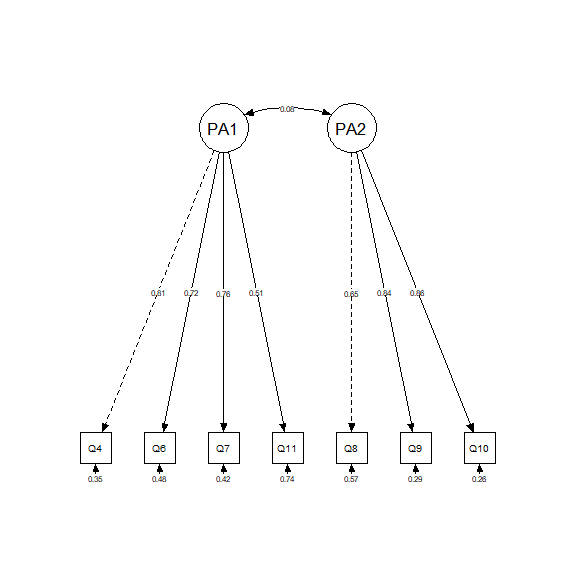

```r
semPaths(cfa.model2, 'path', 'std', style = 'lisrel',
         edge.color = 'black')
```

# 6 Results presentation

In the report, you must include a number of important statements and results pertaining to the CFA,

1. The estimation method e.g. ML, MLR, WLSMV etc.
2. The model specification and the theoretical background supporting the model.
3. Details about the selected fit indices, residuals, MIs, FLs and factor correlations and the accepted cut-off values.
4. Detailed comments on the fit and parameters of the tested models. This is usually done in reference to summary tables.
5. Details about the revision process, i.e. item deletion, addition of correlated errors or any other modifications and the effects on the model fit. Also mention the reasons e.g. high SRs, low Fls etc.
6. Summary tables, which outlines the model fit indices, model comparison, FLs, communalities, omega, and factor correlations.
7. The path diagram (most of the time, of the final model). This may be requested by some journals.

Fit indices of the models.

| Model | $\chi^2$(df) | $P$ | SRMR | RMSEA | 90% CI | CFI | TLI | AIC | BIC |
| --- | --- | --- | --- | --- | --- | --- | --- | --- | --- |
| Model | 27.4(19) | 0.096 | 0.079 | 0.063 | 0.000, 0.112 | 0.973 | 0.960 | 3166 | 3217 |
| Model 2 | 14.5(13) | 0.342 | 0.063 | 0.033 | 0.000, 0.104 | 0.994 | 0.990 | 2791 | 2836 |

Factor loadings and reliability of Model 2.

| Factor | Item | Factor loading | Omega |
| --- | --- | --- | --- |
| Affinity | Q4 | 0.806 | 0.809 |
|  | Q6 | 0.718 |  |
|  | Q7 | 0.762 |  |
|  | Q11 | 0.509 |  |
| Importance | Q8 | 0.653 | 0.836 |
|  | Q9 | 0.844 |  |
|  | Q10 | 0.858 |  |

Factor correlation: Affinity $\leftrightarrow$ Importance, $r = 0.078$

The path diagram of Model 2.

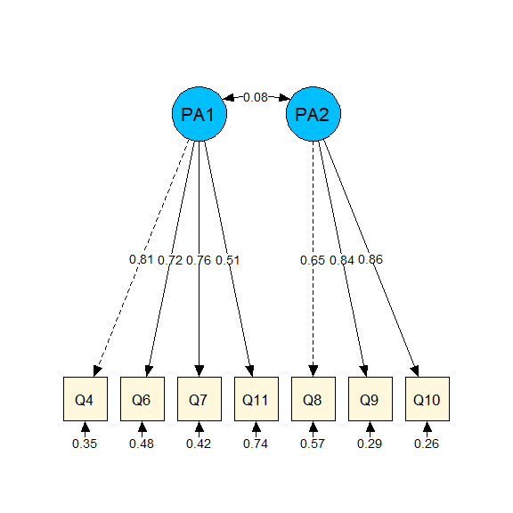

# References

Brown, T. A. (2015). *Confirmatory factor analysis for applied research*. New York: The Guilford Press.

Epskamp, S. (2022). *semPlot: Path diagrams and visual analysis of various SEM packages’ output*. Retrieved from https://github.com/SachaEpskamp/semPlot

Hair, J. F., Black, W. C., Babin, B. J., & Anderson, R. E. (2010). *Multivariate data analysis*. New Jersey: Prentice Hall.

Jorgensen, T. D., Pornprasertmanit, S., Schoemann, A. M., & Rosseel, Y. (2022). *semTools: Useful tools for structural equation modeling*. Retrieved from https://github.com/simsem/semTools/wiki

Muthen, L. K. (2012, May). Setting factor variance to 1 in mplus. Retrieved from http://www.statmodel.com/discussion/messages/9/980.html?1602971916

Revelle, W. (2023). *Psych: Procedures for psychological, psychometric, and personality research*. Retrieved from https://personality-project.org/r/psych/ https://personality-project.org/r/psych-manual.pdf

Rosseel, Y., Jorgensen, T. D., & Rockwood, N. (2023). *Lavaan: Latent variable analysis*. Retrieved from https://lavaan.ugent.be

Schreiber, J. B., Nora, A., Stage, F. K., Barlow, E. A., & King, J. (2006). Reporting structural equation modeling and confirmatory factor analysis results: A review. *The Journal of Educational Research*, *99*(6), 323–338.

[^1]: The regression weight of an item from a factor is fixed to 1. Another approach in CFA is to fix the factor variance to 1 (Brown, 2015). This supposedly gives same model fit (Muthen, 2012)
[^2]: The latent variable (factor) is an unobserved variable, thus it has to be scaled by a method to define its metric/unit of measurement. This is done by fixing either the item regression weight or the factor variance to 1.
[^3]: model with same number of items, but with different model specifications e.g. number of factors